# Hospital Readmission Analysis

Dina

22 dec.2025

##Introduction

This project explores patient profiles associated with hospital readmission using multivariate statistical methods.  
The objective is to identify homogeneous patient groups and interpret the main factors associated with readmission risk.

##Data description

- Source: Kaggle
- Number of observations: 101,766
- Number of variables: 50
- Description of key variables:

The dataset includes a wide range of variables describing patient hospitalizations.  
For the purposes of this analysis, particular attention is given to the following numerical variables:

-time_in_hospital: number of days the patient stayed in the hospital. -num_lab_procedures: number of laboratory tests performed during the hospital stay. -num_procedures: number of medical procedures carried out. -num_medications: number of distinct medications administered. -number_diagnoses: number of diagnoses recorded for the patient. -number_emergency: number of emergency room visits prior to the hospitalization. -number_inpatient: number of previous inpatient visits. -number_outpatient: number of outpatient visits prior to admission.

These variables capture the intensity of medical care, patient complexity, and healthcare utilization patterns, which are key factors for understanding hospital readmission risk.

##Data preprocessing

```r
#Load required packages
library(tidyverse)
library(FactoMineR)
library(factoextra)
#Load dataset
data <- read_csv("diabetic_data.csv")
#View(data)
glimpse(data)
```

```
## Rows: 101,766
## Columns: 50
## $ encounter_id               <dbl> 2278392, 149190, 64410, 500364, 16680, 3575…
## $ patient_nbr                <dbl> 8222157, 55629189, 86047875, 82442376, 4251…
## $ race                       <chr> "Caucasian", "Caucasian", "AfricanAmerican"…
## $ gender                     <chr> "Female", "Female", "Female", "Male", "Male…
## $ age                        <chr> "[0-10)", "[10-20)", "[20-30)", "[30-40)", …
## $ weight                     <chr> "?", "?", "?", "?", "?", "?", "?", "?", "?"…
## $ admission_type_id          <dbl> 6, 1, 1, 1, 1, 2, 3, 1, 2, 3, 1, 2, 1, 1, 3…
## $ discharge_disposition_id   <dbl> 25, 1, 1, 1, 1, 1, 1, 1, 1, 3, 1, 1, 3, 6, …
## $ admission_source_id        <dbl> 1, 7, 7, 7, 7, 2, 2, 7, 4, 4, 7, 4, 7, 7, 2…
## $ time_in_hospital           <dbl> 1, 3, 2, 2, 1, 3, 4, 5, 13, 12, 9, 7, 7, 10…
## $ payer_code                 <chr> "?", "?", "?", "?", "?", "?", "?", "?", "?"…
## $ medical_specialty          <chr> "Pediatrics-Endocrinology", "?", "?", "?", …
## $ num_lab_procedures         <dbl> 41, 59, 11, 44, 51, 31, 70, 73, 68, 33, 47,…
```

[output cut: 37 more lines]

```r
#Data cleaning
data_clean <- data%>%
  mutate(across(where(is.character),~na_if(.,"?")))
colSums(is.na(data_clean))
```

```
##             encounter_id              patient_nbr                     race
##                        0                        0                     2273
##                   gender                      age                   weight
##                        0                        0                    98569
##        admission_type_id discharge_disposition_id      admission_source_id
##                        0                        0                        0
##         time_in_hospital               payer_code        medical_specialty
##                        0                    40256                    49949
##       num_lab_procedures           num_procedures          num_medications
##                        0                        0                        0
##        number_outpatient         number_emergency         number_inpatient
##                        0                        0                        0
##                   diag_1                   diag_2                   diag_3
##                       21                      358                     1423
##         number_diagnoses            max_glu_serum                A1Cresult
##                        0                        0                        0
##                metformin              repaglinide              nateglinide
##                        0                        0                        0
##           chlorpropamide              glimepiride            acetohexamide
##                        0                        0                        0
##                glipizide                glyburide              tolbutamide
##                        0                        0                        0
##             pioglitazone            rosiglitazone                 acarbose
##                        0                        0                        0
##                 miglitol             troglitazone               tolazamide
##                        0                        0                        0
##                  examide              citoglipton                  insulin
##                        0                        0                        0
##      glyburide-metformin      glipizide-metformin glimepiride-pioglitazone
##                        0                        0                        0
##  metformin-rosiglitazone   metformin-pioglitazone                   change
##                        0                        0                        0
##              diabetesMed               readmitted
##                        0                        0
```

```r
data_reduced <- data_clean %>%
  select(-weight, -payer_code, -medical_specialty)
#View(data_reduced)
```

##Principal Component Analysis (PCA)

```r
#keep only numeric variables for PCA
data_numeric <- data_reduced %>%
  select(where(is.numeric))
dim(data_numeric) #13 variables // 101766 observations
```

```
## [1] 101766     13
```

```r
pca_res <- PCA(data_numeric, scale.unit = TRUE, graph = FALSE)
summary(pca_res)
```

```
##
## Call:
## PCA(X = data_numeric, scale.unit = TRUE, graph = FALSE)
##
##
## Eigenvalues
##                        Dim.1   Dim.2   Dim.3   Dim.4   Dim.5   Dim.6   Dim.7
## Variance               2.092   1.803   1.355   1.192   1.066   0.955   0.906
## % of var.             16.092  13.869  10.425   9.166   8.197   7.349   6.966
## Cumulative % of var.  16.092  29.961  40.386  49.552  57.749  65.098  72.064
##                        Dim.8   Dim.9  Dim.10  Dim.11  Dim.12  Dim.13
## Variance               0.762   0.733   0.626   0.593   0.509   0.409
## % of var.              5.860   5.640   4.813   4.560   3.913   3.150
## Cumulative % of var.  77.924  83.564  88.378  92.938  96.850 100.000
##
## Individuals (the 10 first)
##                              Dist    Dim.1    ctr   cos2    Dim.2    ctr   cos2
## 1                        |  6.773 | -3.493  0.006  0.266 | -3.199  0.006  0.223
## 2                        |  2.459 | -0.167  0.000  0.005 | -0.419  0.000  0.029
## 3                        |  3.807 | -0.859  0.000  0.051 | -0.100  0.000  0.001
## 4                        |  2.254 | -0.841  0.000  0.139 | -0.190  0.000  0.007
## 5                        |  2.923 | -2.184  0.002  0.558 | -0.577  0.000  0.039
## 6                        |  3.654 |  0.396  0.000  0.012 | -0.726  0.000  0.040
## 7                        |  2.738 |  0.246  0.000  0.008 | -0.865  0.000  0.100
## 8                        |  3.096 |  0.078  0.000  0.001 |  0.139  0.000  0.002
## 9                        |  3.971 |  2.310  0.003  0.338 | -2.164  0.003  0.297
## 10                       |  3.397 |  1.131  0.001  0.111 | -1.814  0.002  0.285
##                             Dim.3    ctr   cos2
## 1                        |  0.436  0.000  0.004 |
## 2                        |  0.284  0.000  0.013 |
## 3                        | -0.358  0.000  0.009 |
## 4                        | -0.188  0.000  0.007 |
## 5                        |  0.230  0.000  0.006 |
## 6                        | -1.639  0.002  0.201 |
## 7                        | -0.592  0.000  0.047 |
## 8                        |  0.122  0.000  0.002 |
## 9                        | -0.267  0.000  0.005 |
## 10                       | -0.564  0.000  0.028 |
##
## Variables (the 10 first)
##                             Dim.1    ctr   cos2    Dim.2    ctr   cos2    Dim.3
## encounter_id             |  0.294  4.124  0.086 |  0.741 30.491  0.550 | -0.252
## patient_nbr              |  0.268  3.433  0.072 |  0.688 26.238  0.473 | -0.225
## admission_type_id        | -0.077  0.282  0.006 | -0.290  4.679  0.084 | -0.004
## discharge_disposition_id |  0.144  0.986  0.021 | -0.377  7.890  0.142 |  0.200
## admission_source_id      | -0.061  0.180  0.004 | -0.056  0.172  0.003 |  0.481
## time_in_hospital         |  0.679 22.027  0.461 | -0.347  6.667  0.120 |  0.069
## num_lab_procedures       |  0.504 12.158  0.254 | -0.159  1.404  0.025 |  0.112
## num_procedures           |  0.430  8.822  0.185 | -0.298  4.939  0.089 | -0.384
## num_medications          |  0.763 27.850  0.583 | -0.260  3.745  0.068 | -0.095
## number_outpatient        |  0.141  0.949  0.020 |  0.263  3.828  0.069 |  0.261
##                             ctr   cos2
## encounter_id              4.688  0.064 |
## patient_nbr               3.725  0.050 |
## admission_type_id         0.001  0.000 |
## discharge_disposition_id  2.946  0.040 |
## admission_source_id      17.050  0.231 |
## time_in_hospital          0.353  0.005 |
## num_lab_procedures        0.923  0.013 |
## num_procedures           10.907  0.148 |
## num_medications           0.669  0.009 |
## number_outpatient         5.045  0.068 |
```

```r
pca_res$eig #eigenvalues
```

```
##         eigenvalue percentage of variance cumulative percentage of variance
## comp 1   2.0920130              16.092408                          16.09241
## comp 2   1.8029644              13.868957                          29.96137
## comp 3   1.3552288              10.424837                          40.38620
## comp 4   1.1915708               9.165929                          49.55213
## comp 5   1.0656272               8.197133                          57.74926
## comp 6   0.9553827               7.349098                          65.09836
## comp 7   0.9055392               6.965686                          72.06405
## comp 8   0.7617820               5.859861                          77.92391
## comp 9   0.7332502               5.640386                          83.56430
## comp 10  0.6257347               4.813344                          88.37764
## comp 11  0.5927912               4.559932                          92.93757
## comp 12  0.5086562               3.912740                          96.85031
## comp 13  0.4094594               3.149688                         100.00000
```

```r
round(pca_res$var$contrib[,1:5], 3) #contribution values (5 principal components)
```

```
##                           Dim.1  Dim.2  Dim.3  Dim.4  Dim.5
## encounter_id              4.124 30.491  4.688  0.230  0.110
## patient_nbr               3.433 26.238  3.725  2.157  4.545
## admission_type_id         0.282  4.679  0.001 47.636  6.364
## discharge_disposition_id  0.986  7.890  2.946  0.526  1.964
## admission_source_id       0.180  0.172 17.050  0.094 45.695
## time_in_hospital         22.027  6.667  0.353  1.536  0.065
## num_lab_procedures       12.158  1.404  0.923 19.682  1.124
## num_procedures            8.822  4.939 10.907 12.081  5.679
## num_medications          27.850  3.745  0.669  2.178  0.354
## number_outpatient         0.949  3.828  5.045  9.558  0.243
## number_emergency          0.567  3.846 23.309  3.314 13.161
## number_inpatient          1.813  1.512 29.917  0.537 13.796
## number_diagnoses         16.807  4.590  0.467  0.472  6.898
```

```r
round(pca_res$var$coord, 3) #Coordinates of variables
```

```
##                           Dim.1  Dim.2  Dim.3  Dim.4  Dim.5
## encounter_id              0.294  0.741 -0.252  0.052  0.034
## patient_nbr               0.268  0.688 -0.225  0.160  0.220
## admission_type_id        -0.077 -0.290 -0.004  0.753  0.260
## discharge_disposition_id  0.144 -0.377  0.200  0.079  0.145
## admission_source_id      -0.061 -0.056  0.481  0.033  0.698
## time_in_hospital          0.679 -0.347  0.069 -0.135  0.026
## num_lab_procedures        0.504 -0.159  0.112 -0.484  0.109
## num_procedures            0.430 -0.298 -0.384  0.379 -0.246
## num_medications           0.763 -0.260 -0.095  0.161 -0.061
## number_outpatient         0.141  0.263  0.261  0.337  0.051
## number_emergency          0.109  0.263  0.562  0.199 -0.374
## number_inpatient          0.195  0.165  0.637  0.080 -0.383
## number_diagnoses          0.593  0.288  0.080 -0.075  0.271
```

```r
round(pca_res$var$cos2, 3)
```

```
##                          Dim.1 Dim.2 Dim.3 Dim.4 Dim.5
## encounter_id             0.086 0.550 0.064 0.003 0.001
## patient_nbr              0.072 0.473 0.050 0.026 0.048
## admission_type_id        0.006 0.084 0.000 0.568 0.068
## discharge_disposition_id 0.021 0.142 0.040 0.006 0.021
## admission_source_id      0.004 0.003 0.231 0.001 0.487
## time_in_hospital         0.461 0.120 0.005 0.018 0.001
## num_lab_procedures       0.254 0.025 0.013 0.235 0.012
## num_procedures           0.185 0.089 0.148 0.144 0.061
## num_medications          0.583 0.068 0.009 0.026 0.004
## number_outpatient        0.020 0.069 0.068 0.114 0.003
## number_emergency         0.012 0.069 0.316 0.039 0.140
## number_inpatient         0.038 0.027 0.405 0.006 0.147
## number_diagnoses         0.352 0.083 0.006 0.006 0.074
```

##Clustering

```r
#Coordinates of individuals on the retained PCA components (5 components)
ind_coord <- pca_res$ind$coord[, 1:5]

#k-means
set.seed(123)
km <- kmeans(ind_coord, centers = 4, nstart = 25)
table(km$cluster)
```

```
##
##     1     2     3     4
##  8566 38578 33635 20987
```

```r
data_clustered <- data_reduced
data_clustered$cluster <- factor(km$cluster)
table(data_clustered$cluster)
```

```
##
##     1     2     3     4
##  8566 38578 33635 20987
```

```r
num_cols <- sapply(data_clustered, is.numeric)
data_for_agg <- data_clustered[, c("cluster", names(data_clustered)[num_cols])]

cluster_means <- aggregate(. ~ cluster, data = data_for_agg, mean)
cluster_means
```

```
##   cluster encounter_id patient_nbr admission_type_id discharge_disposition_id
## 1       1     87652057    43120703          5.229629                 5.554284
## 2       2    239837911    81079484          1.593551                 2.536809
## 3       3    106352725    29441172          1.797235                 3.396016
## 4       4    153973522    49624885          1.870301                 5.644351
##   admission_source_id time_in_hospital num_lab_procedures num_procedures
## 1           14.428555         4.084870           36.28064      1.2124679
## 2            5.427446         3.524418           41.42439      0.8833014
## 3            4.529954         3.221079           38.50444      1.0589267
## 4            4.777529         8.008053           56.30743      2.6807071
##   num_medications number_outpatient number_emergency number_inpatient
## 1        15.68317        0.69460658       0.22881158        0.5775158
## 2        14.53111        0.60570792       0.34079009        0.7590077
## 3        12.06686        0.08060056       0.06264308        0.4302958
## 4        25.23881        0.26492591       0.13908610        0.7613284
##   number_diagnoses
## 1         7.114873
## 2         8.309451
## 3         5.894158
## 4         8.367609
```

```r
#View(cluster_means)
```

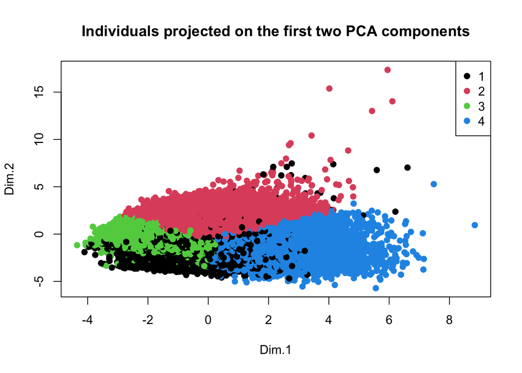

```r
#PCA coordinates (Dim.1 & Dim.2)
pca_ind <- as.data.frame(pca_res$ind$coord[, 1:2])
pca_ind$cluster <- factor(km$cluster)

#plot
plot(pca_ind$Dim.1, pca_ind$Dim.2, col = pca_ind$cluster,
  pch = 19, xlab = "Dim.1", ylab = "Dim.2",
  main = "Individuals projected on the first two PCA components")

legend("topright", legend = levels(pca_ind$cluster),
  col = 1:length(levels(pca_ind$cluster)), pch = 19)
```